# Time series data visualization

## 0.1 Requirements for this lab

In this lab, you are required to use the skills learned from Module 11 to create a R Markdown which integrates the hourly data into weekly and monthly data and then plot the time series data sets at different temporal scales (hourly, weekly and monthly scales).

#### Please create a R Markdown file, set the output format as html_document or html_document2. Finally knit the R Markdown file into the HTML file.

#### Please use the data provided to conduct a lab **Time series data visualization** based on the steps mentioned below.

- > Steps:
  > 1. Install and load required packages.
  > 2. Load and inspect the dataset.  
  >    *-* Original data: Three-year crime data from 2017-09-01 to 2020-08-31  
  >    *-* Select two-years: from 2018-01-01 00:00:00 to 2019-12-31 23:00:00  
  >    *-* Integrate the two-year time series data into weekly and monthly data based on the skills in Module10, Lesson 10.1.  
  >    *-* Please check your data after the integrating procedure. Since the first week of a year may not start from the first day of the year, so you need to remove the weeks not in 2018 and not 2019. In this lab,weeks at 2020 should be removed before plotting. *-* Please check the website here for more information about date formats. https://www.rdocumentation.org/packages/base/versions/3.6.2/topics/strptime
  > 3. Please refer to the code below for create different parts from the original dates (e.g., hours, days, dates, years, months, weekdays). In the code below, you need the packages “tidyverse”, “zoo”. For example,

  ```
  bat_train_new<-bat_train %>%
  mutate(hour = hour(bat_train$Date),week= weekdays(bat_train$Date),
  month = month(bat_train$Date),
  year=year(bat_train$Date)) %>% #Get the hours, months and years from Date
  mutate(weeknum= strftime(Date, format = '%V')) %>%   #Get the week number in a year.
  mutate(dates= as.Date(strftime(Date, format = '%F')))  #Remove the time in Date and get only the date like 2018-01-01.
  ```

  > 4. Plot a time series visualization with two-year data at a hourly scale. For this plot, you can use orginal dates. Please label the x axis using scale_x_datetime() for the date and time format (e.g. month/day/year-time: 04/24/18-00:00:00).

  ```
      >
      Please note: here the date is a standard date-time format, so you can directly use scale_x_datetime() function with ggplot() and format the x axis for required format.
      >
  ```

  > 5. Plot a time series visualization with two-year data at a weekly scale. For this plot, you need to group the week number and year. Please label the x axis using scale_x_date() for the date format (e.g. year-week number: 2018/05).

  > 6. Plot a time series visualization with two-year data at a monthly scale. For this plot, you need to group the month and year. Please label the x axis using scale_x_date() for the date format (e.g. year-month abbr:2018-Jan).

  > 7. Plot the two-year time series at a monthly scale using stacked style. This means the x-axis is one year(12 months).Please label the x axis using scale_x_date() for the date format (e.g.month abbr: Jan).

#### Please name your file as *Yourname_11.2_Time series data visualization.RMD*

#### Please knit your R Markdown file into a HTML file and submit the HTML file. Please have the codes and graphs displayed in your file.

## 0.2 Create plots at different scales

### Plot at a hourly scale

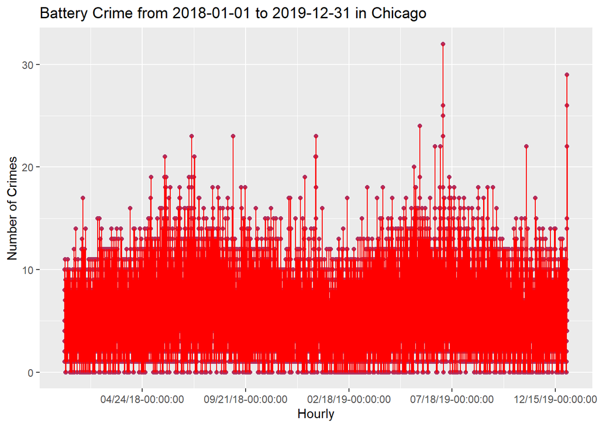

### Plot at a weekly scale

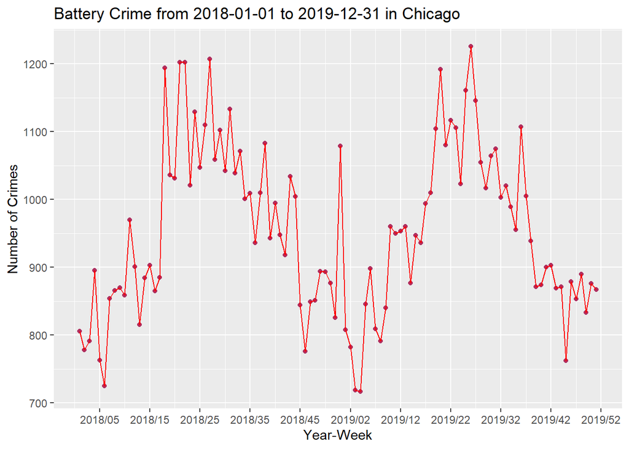

### Plot at a monthly scale

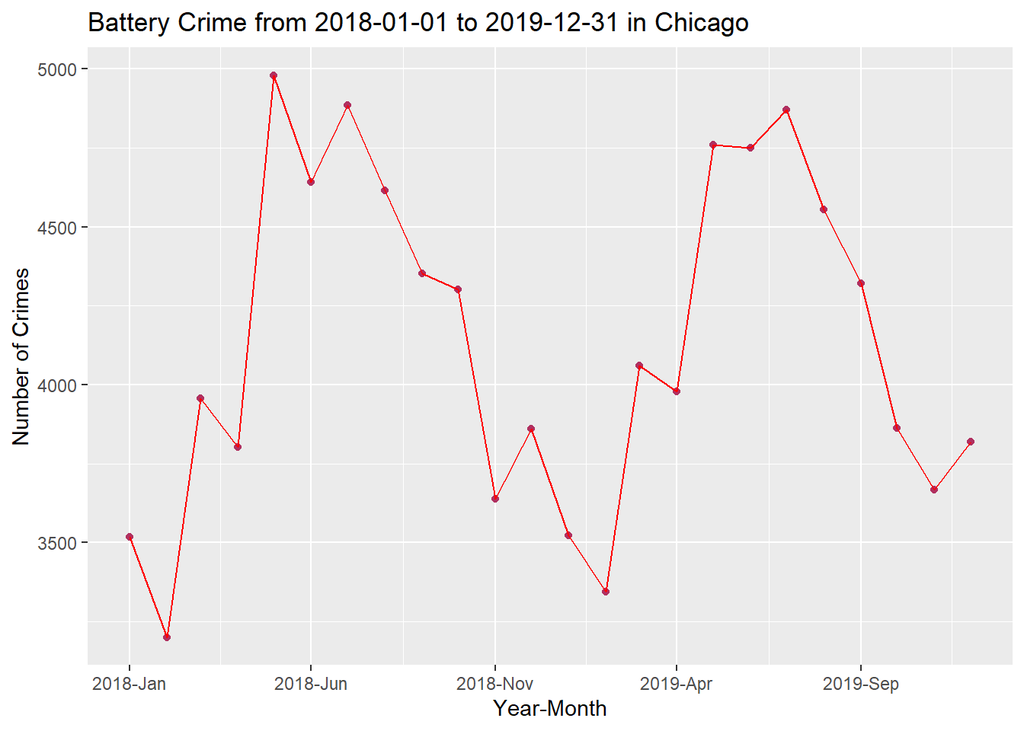

### Create stacked time series plots at a monthly scale

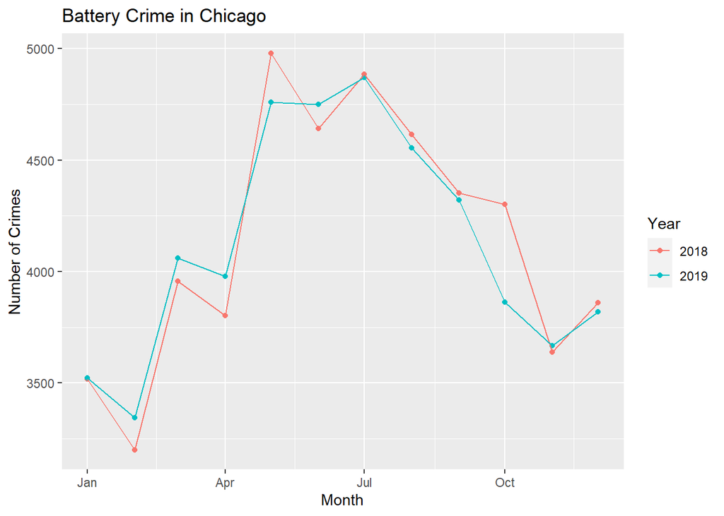